# Trachea FACS Notebook

Enter the directory of the maca folder on your drive and the name of the tissue you want to analyze.

Load the requisite packages and some additional helper functions.

```r
library(here)
source(here("00_data_ingest", "02_tissue_analysis_rmd", "boilerplate.R"))
tiss = load_tissue_facs(tissue_of_interest)
```

Visualize top genes in principal components

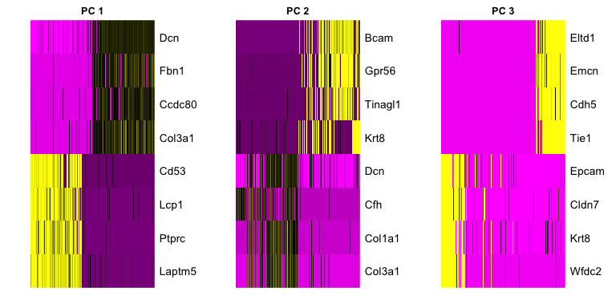

Later on (in FindClusters and TSNE) you will pick a number of principal components to use. This has the effect of keeping the major directions of variation in the data and, ideally, supressing noise. There is no correct answer to the number to use, but a decent rule of thumb is to go until the plot plateaus.

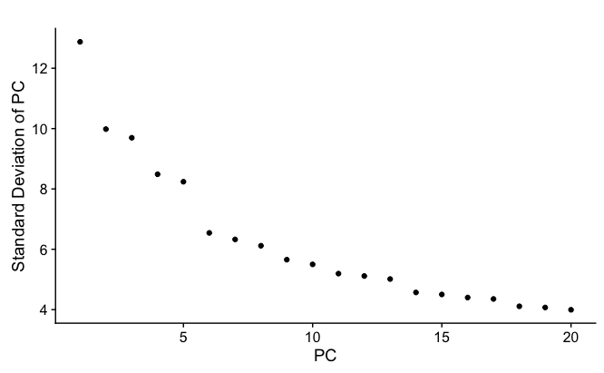

```r
PCElbowPlot(object = tiss)
```

Choose the number of principal components to use.

```r
# Set number of principal components.
n.pcs = 5
```

The clustering is performed based on a nearest neighbors graph. Cells that have similar expression will be joined together. The Louvain algorithm looks for groups of cells with high modularity–more connections within the group than between groups. The resolution parameter determines the scale…higher resolution will give more clusters, lower resolution will give fewer.

For the top-level clustering, aim to under-cluster instead of over-cluster. It will be easy to subset groups and further analyze them below.

```r
# Set resolution
res.used <- 0.3
tiss <- FindClusters(object = tiss, reduction.type = "pca", dims.use = 1:n.pcs,
    resolution = res.used, print.output = 0, save.SNN = TRUE, force.recalc = TRUE)
```

To visualize

```r
# If cells are too spread out, you can raise the perplexity. If you have few cells, try a lower perplexity (but never less than 10).
tiss <- RunTSNE(object = tiss, dims.use = 1:n.pcs, seed.use = 10, perplexity=30)
```

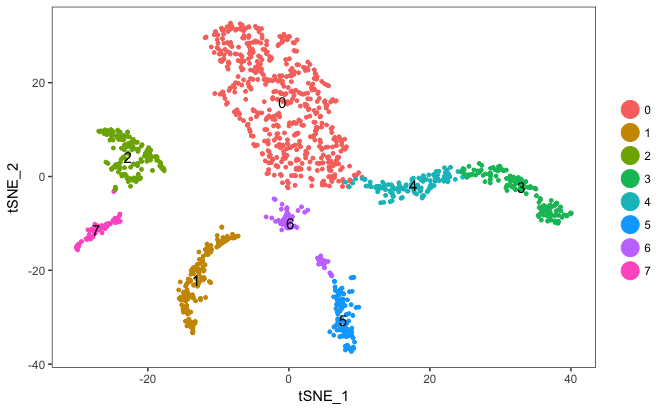

```r
# note that you can set do.label=T to help label individual clusters
TSNEPlot(object = tiss, do.label = T)
```

Check expression of genes of interset.

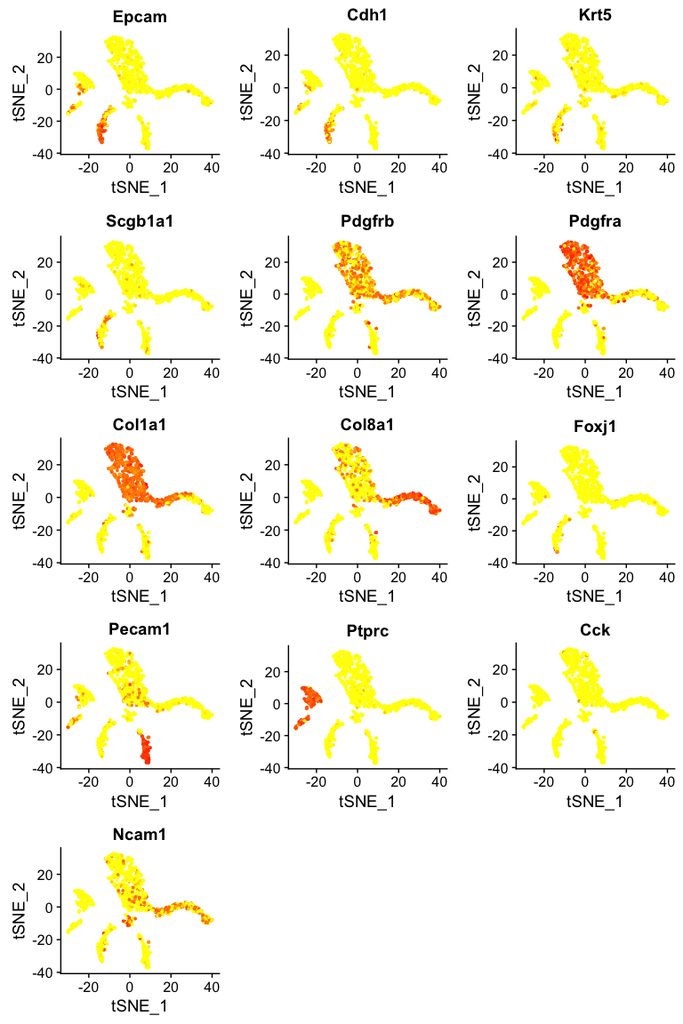

Dotplots let you see the intensity of exppression and the fraction of cells expressing for each of your genes of interest.

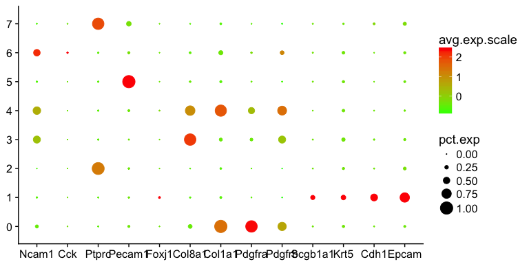

How big are the clusters?

```r
table(tiss@ident)
```

```
  0   1   2   3   4   5   6   7
551 156 140 139 114 110  73  67
```

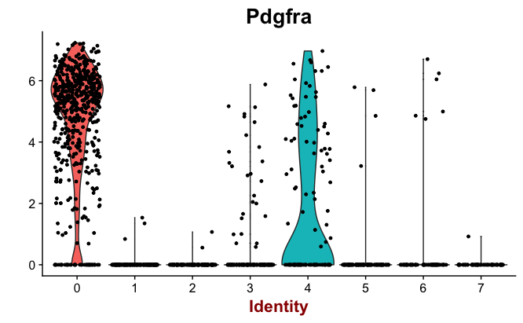

```r
VlnPlot(tiss, features.plot = "Pdgfra")
```

```r
#TRACHEA SUPP FIGURE 4
```

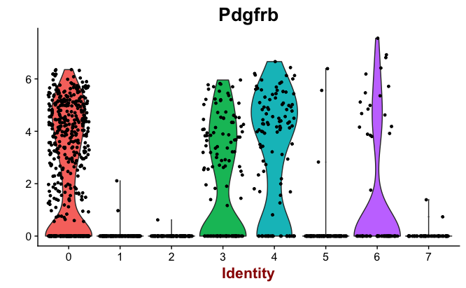

```r
VlnPlot(tiss, features.plot = "Pdgfrb")
```

```r
#TRACHEA SUPP FIGURE 4
```

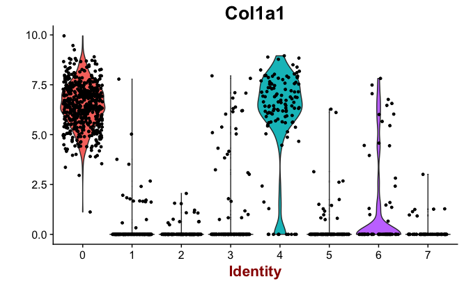

```r
VlnPlot(tiss, features.plot = "Col1a1")
```

```r
#TRACHEA SUPP FIGURE 4
```

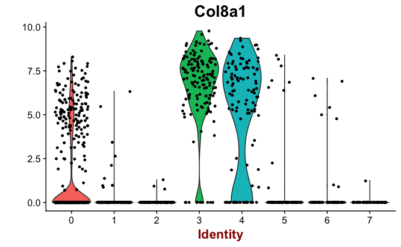

```r
VlnPlot(tiss, features.plot = "Col8a1")
```

```r
#TRACHEA SUPP FIGURE 4
```

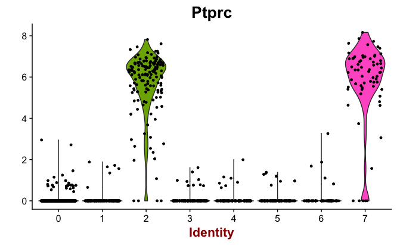

```r
VlnPlot(tiss, features.plot = "Ptprc")
```

```r
#TRACHEA SUPP FIGURE 4
```

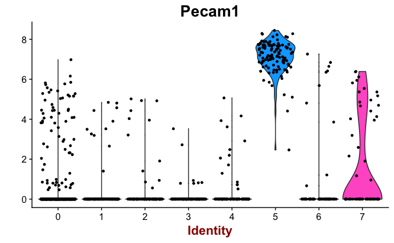

```r
VlnPlot(tiss, features.plot = "Pecam1")
```

```r
#TRACHEA SUPP FIGURE 4
```

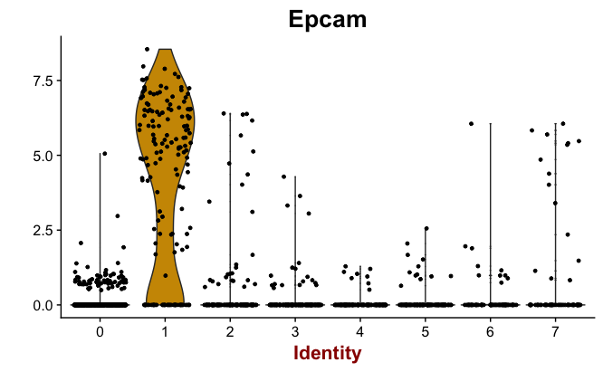

```r
VlnPlot(tiss, features.plot = "Epcam")
```

```r
#TRACHEA SUPP FIGURE 4
```

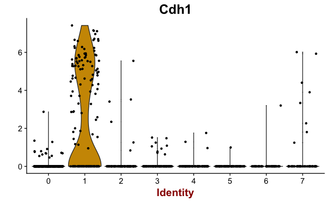

```r
VlnPlot(tiss, features.plot = "Cdh1")
```

```r
#TRACHEA SUPP FIGURE 4
```

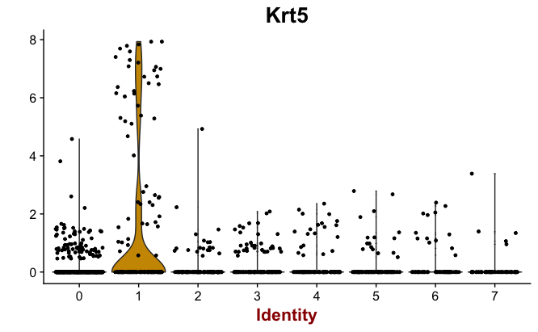

```r
VlnPlot(tiss, features.plot = "Krt5")
```

```r
#TRACHEA SUPP FIGURE 4
```

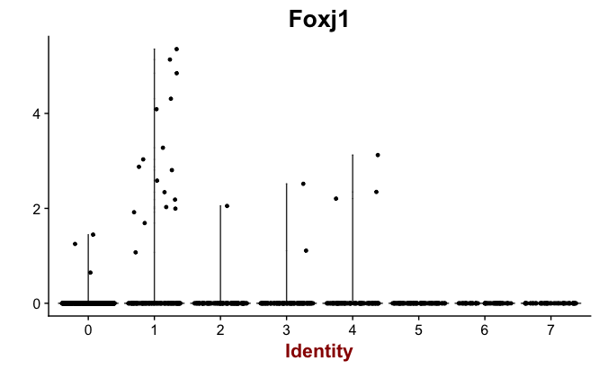

```r
VlnPlot(tiss, features.plot = "Foxj1")
```

```r
#TRACHEA SUPP FIGURE 4
```

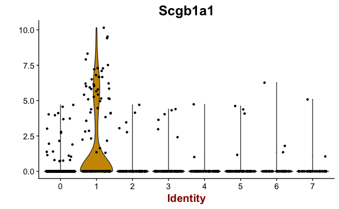

```r
VlnPlot(tiss, features.plot = "Scgb1a1")
```

```r
#TRACHEA SUPP FIGURE 4
```

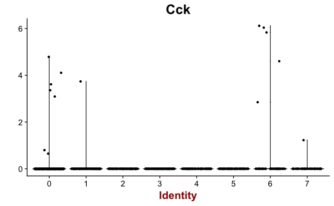

```r
VlnPlot(tiss, features.plot = "Cck")
```

```r
#TRACHEA SUPP FIGURE 4
```

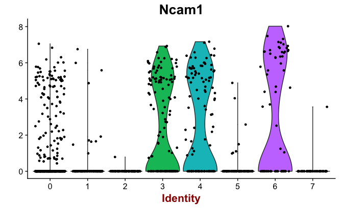

```r
VlnPlot(tiss, features.plot = "Ncam1")
```

```r
#TRACHEA SUPP FIGURE 4
```

Which markers identify a specific cluster?

```r
clust.markers <- FindMarkers(object = tiss, ident.1 = 6, only.pos = TRUE, min.pct = 0.25, thresh.use = 0.25)
```

[output not shown]

[output cut: 43 more lines]

[output not shown]

```r
print(x = head(x= clust.markers, n = 50))
```

|  | p_val | avg_logFC | pct.1 | pct.2 | p_val_adj |
| --- | --- | --- | --- | --- | --- |
| Des | 2.926408e-75 | 3.7340435 | 0.630 | 0.050 | 6.830529e-71 |
| Notch3 | 2.175785e-63 | 3.2426602 | 0.603 | 0.056 | 5.078501e-59 |
| Itga7 | 1.576654e-60 | 4.2209276 | 0.479 | 0.033 | 3.680067e-56 |
| Fgfr4 | 1.083088e-56 | 4.8121182 | 0.315 | 0.010 | 2.528035e-52 |
| Chrdl2 | 8.166843e-52 | 4.7524392 | 0.315 | 0.013 | 1.906223e-47 |
| Chodl | 8.770078e-51 | 4.2887864 | 0.397 | 0.026 | 2.047024e-46 |
| Rcan2 | 8.589144e-42 | 3.5764609 | 0.493 | 0.060 | 2.004792e-37 |
| Rgs4 | 1.443890e-39 | 5.2410411 | 0.288 | 0.016 | 3.370185e-35 |
| Fam132b | 8.886327e-34 | 5.7601823 | 0.301 | 0.024 | 2.074157e-29 |
| Myh11 | 5.839389e-33 | 5.3699600 | 0.260 | 0.017 | 1.362972e-28 |

[output cut: 40 more lines]

You can also compute all markers for all clusters at once. This may take some time.

```r
#tiss.markers <- FindAllMarkers(object = tiss, only.pos = TRUE, min.pct = 0.25, thresh.use = 0.25)
```

Display the top markers you computed above.

```r
#tiss.markers %>% group_by(cluster) %>% top_n(5, avg_diff)
```

## Assigning cell type identity to clusters

At a coarse level, we can use canonical markers to match the unbiased clustering to known cell types:

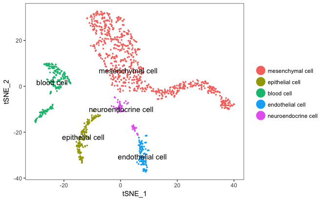

```r
# stash current cluster IDs
tiss <- StashIdent(object = tiss, save.name = "cluster.ids")
# enumerate current cluster IDs and the labels for them
cluster.ids <- c(0, 1, 2, 3, 4, 5, 6, 7)
free_annotation = c("mesenchymal 1","NA","NA","mesenchymal 2","mesenchymal 3","NA","putative neuroendocrine cell","NA")
cell_ontology_class <- c("mesenchymal cell","epithelial cell","blood cell","mesenchymal cell","mesenchymal cell","endothelial cell","neuroendocrine cell","blood cell")
validate_cell_ontology(cell_ontology_class)
cell_ontology_id = convert_to_cell_ontology_id(cell_ontology_class)
tiss@meta.data[,'cell_ontology_class'] <- plyr::mapvalues(x = tiss@ident, from = cluster.ids, to = cell_ontology_class)
tiss@meta.data[,'cell_ontology_id'] <- plyr::mapvalues(x = tiss@ident, from = cluster.ids, to = cell_ontology_id)
tiss@meta.data[,'free_annotation'] <- plyr::mapvalues(x = tiss@ident, from = cluster.ids, to = free_annotation)
tiss@meta.data[tiss@cell.names,'cell_ontology_class'] <- as.character(tiss@meta.data$cell_ontology_class)
tiss@meta.data[tiss@cell.names,'cell_ontology_id'] <- as.character(tiss@meta.data$cell_ontology_id)
tiss@meta.data[tiss@cell.names,'free_annotation'] <- as.character(tiss@meta.data$free_annotation)
TSNEPlot(object = tiss, do.label = TRUE, pt.size = 0.5, group.by='cell_ontology_class')
```

```r
# TRACHEA SUPP FIGURE 1, WOULD BE NICE TO INCLUDE FREE_ANNOTATION LABELS
```

## Checking for batch effects

Color by metadata, like plate barcode, to check for batch effects.

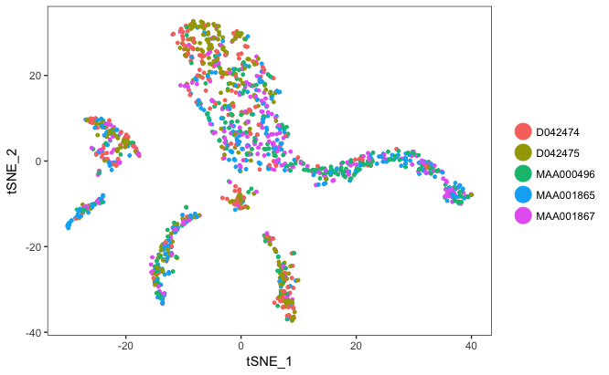

```r
TSNEPlot(object = tiss, do.return = TRUE, group.by = "plate.barcode")
```

Print a table showing the count of cells in each identity category from each plate.

```r
table(as.character(tiss@ident), as.character(tiss@meta.data$plate.barcode))
```

```
    D042474 D042475 MAA000496 MAA001865 MAA001867
  0     105     128        92       104       122
  1      10      38        32        49        27
  2      37      34        13        28        28
  3       3       2        43        43        48
  4       6       1        55        26        26
  5      36      42        16         9         7
  6      21      28         7         8         9
  7       5       5         9        36        12
```

# Save the Robject for later

When you save the annotated tissue, please give it a name.

```r
filename = here('00_data_ingest', '04_tissue_robj_generated',
                     paste0("facs", tissue_of_interest, "_seurat_tiss.Robj"))
print(filename)
```

```
[1] "/Users/william/Documents/GitHub/tabula-muris/00_data_ingest/04_tissue_robj_generated/facsTrachea_seurat_tiss.Robj"
```

```r
save(tiss, file=filename)
```

```r
# To reload a saved object
# filename = here('00_data_ingest', '04_tissue_robj_generated',
#                      paste0("facs", tissue_of_interest, "_seurat_tiss.Robj"))
# load(file=filename)
```

# Export the final metadata

So that Biohub can easily combine all your cell_ontology_classs, please export them as a simple csv.

```r
head(tiss@meta.data)
```

|  | nGene | nReads | orig.ident | plate.barcode | mouse.id | tissue | subtissue | FACS.selection | mouse.sex | percent.ercc | free_annotation | cell_ontology_class | percent.ribo | res.0.3 | res.0.4 | res.0.2 | cluster.ids | cell_ontology_id |
| --- | --- | --- | --- | --- | --- | --- | --- | --- | --- | --- | --- | --- | --- | --- | --- | --- | --- | --- |
| A1.D042475.3_9_M.1.1 | 2694 | 709803 | Trachea | D042475 | 3_9_M | Trachea | NA | Multiple | M | 0.02758187 | NA | endothelial cell | 0.01226819 | 5 | 5 | 4 | 5 | CL:0000115 |
| A1.MAA000496.3_10_M.1.1 | 2909 | 458888 | Trachea | MAA000496 | 3_10_M | Trachea | NA | Multiple | M | 0.03378371 | mesenchymal 2 | mesenchymal cell | 0.02334557 | 3 | 3 | 1 | 3 | CL:0008019 |
| A1.MAA001865.3_38_F.1.1 | 2208 | 473414 | Trachea | MAA001865 | 3_38_F | Trachea | NA | Multiple | F | 0.02997482 | mesenchymal 2 | mesenchymal cell | 0.01257462 | 3 | 3 | 1 | 3 | CL:0008019 |
| A1.MAA001867.3_39_F.1.1 | 3746 | 646348 | Trachea | MAA001867 | 3_39_F | Trachea | NA | Multiple | F | 0.01014439 | mesenchymal 2 | mesenchymal cell | 0.02163695 | 3 | 3 | 1 | 3 | CL:0008019 |
| A10.D042474.3_8_M.1.1 | 3989 | 1251084 | Trachea | D042474 | 3_8_M | Trachea | NA | Multiple | M | 0.00750942 | mesenchymal 1 | mesenchymal cell | 0.01436035 | 0 | 1 | 0 | 0 | CL:0008019 |
| A10.D042475.3_9_M.1.1 | 1987 | 391638 | Trachea | D042475 | 3_9_M | Trachea | NA | Multiple | M | 0.03117215 | NA | endothelial cell | 0.01310904 | 5 | 5 | 4 | 5 | CL:0000115 |

## First subset

```r
# Subset data based on cluster id
#subtiss <- SubsetData(object = tiss, ident.use = c(3), do.center = F, do.scale = F, cells.use = )
# To subset data based on cell_ontology_class or other metadata, you can explicitly pass cell names
#cells.to.use = tiss@cell.names[which(tiss@meta.data$mouse.sex == 'F')]
subtiss <- SubsetData(object = tiss, ident.use = c(1), do.center = F, do.scale = F)
```

```r
subtiss <- NormalizeData(object = subtiss)
subtiss <- ScaleData(object = subtiss)
```

```
[1] "Scaling data matrix"
```

Run Principal Component Analysis.

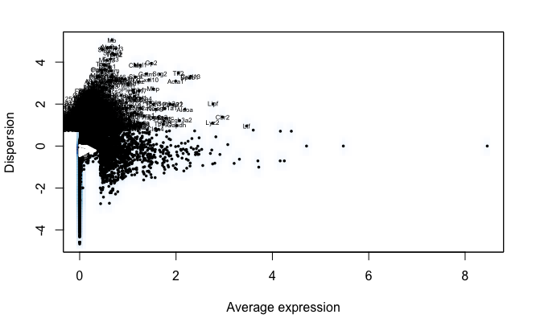

```r
subtiss <- FindVariableGenes(object = subtiss, do.plot = TRUE, x.high.cutoff = Inf, y.cutoff = 0.8)
```

```r
subtiss <- RunPCA(object = subtiss, pcs.compute = 20, weight.by.var = F)
```

```
[1] "PC1"
 [1] "Scgb1a1"       "4921531C22Rik" "Hist1h4h"      "Hist1h1e"      "2900060B14Rik"
 [6] "Scgb3a1"       "Muc5b"         "Rab26"         "Serpine1"      "Hist4h4"
[11] "Sbpl"          "Rad51ap2"      "Mphosph9"      "Hist1h2bh"     "Tulp2"
[16] "Kctd12"        "Rnu12"         "Hist1h3e"      "A330009N23Rik" "Fgd4"
[21] "Pigr"          "Zfp407"        "Cnnm2"         "Bpifb1"        "Mon2"
[26] "4930414L22Rik" "Dmbt1"         "Lyz2"          "Hist1h4d"      "Muc4"
[1] ""
 [1] "Prnp"      "Klf13"     "Tiparp"    "Atp1b3"    "Foxo1"     "Eid1"      "Sgk1"
 [8] "Cnp"       "Galntl4"   "Krt5"      "Sepp1"     "Aldoa"     "Mettl7a1"  "Gpm6b"
[15] "Ccdc3"     "Sdc1"      "Gapdh"     "Igfbp7"    "Ndufa9"    "Egr2"      "Ncln"
[22] "Secisbp2l" "Pmp22"     "Crlf1"     "Adh7"      "Gnl2"      "Atg3"      "Cdkn1b"
[29] "Gal3st1"   "Fundc2"
[1] ""
[1] ""
```

[output cut: 59 more lines]

```r
subtiss <- ProjectPCA(object = subtiss, do.print = FALSE)
```

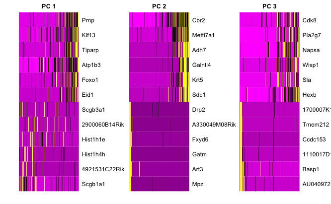

```r
# If this fails for your subset, it may be that cells.use is more cells than you have left! Try reducing it.
PCHeatmap(object = subtiss, pc.use = 1:3, cells.use = 313, do.balanced = TRUE, label.columns = FALSE, num.genes = 12)
```

Later on (in FindClusters and TSNE) you will pick a number of principal components to use. This has the effect of keeping the major directions of variation in the data and, ideally, supressing noise. There is no correct answer to the number to use, but a decent rule of thumb is to go until the plot plateaus.

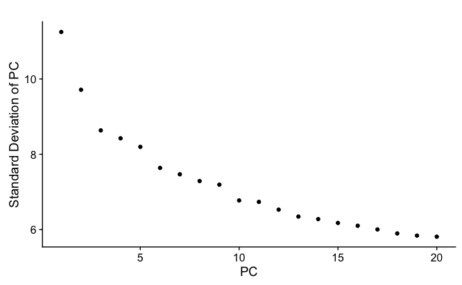

```r
PCElbowPlot(object = subtiss)
```

Choose the number of principal components to use.

```r
# Set number of principal components.
sub.n.pcs = 4
```

The clustering is performed based on a nearest neighbors graph. Cells that have similar expression will be joined together. The Louvain algorithm looks for groups of cells with high modularity–more connections within the group than between groups. The resolution parameter determines the scale…higher resolution will give more clusters, lower resolution will give fewer.

```r
# Set resolution
sub.res.used <- .3
subtiss <- FindClusters(object = subtiss, reduction.type = "pca", dims.use = 1:sub.n.pcs,
    resolution = sub.res.used, force.recalc = TRUE ,print.output = 0, save.SNN = TRUE)
```

To visualize

```r
# If cells are too spread out, you can raise the perplexity. If you have few cells, try a lower perplexity (but never less than 10).
subtiss <- RunTSNE(object = subtiss, dims.use = 1:sub.n.pcs, seed.use = 10, perplexity=20)
```

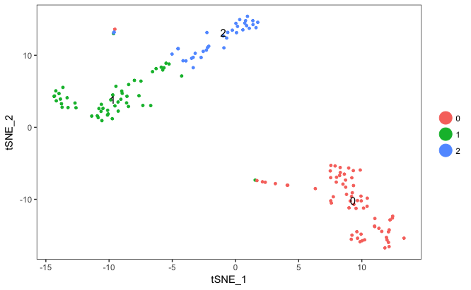

```r
# note that you can set do.label=T to help label individual clusters
TSNEPlot(object = subtiss, do.label = T)
```

```r
#subtiss.markers <- FindAllMarkers(object = subtiss, only.pos = TRUE, min.pct = 0.25, thresh.use = 0.25)
```

```r
#subtiss.markers %>% group_by(cluster) %>% top_n(6, avg_diff)
```

Check expression of genes of interset.

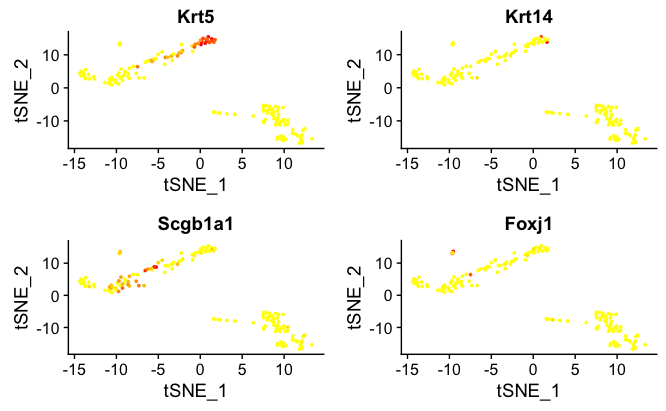

```r
genes_to_check = c('Krt5', 'Krt14', 'Scgb1a1', 'Foxj1')
FeaturePlot(subtiss, genes_to_check, pt.size = 1)
```

```r
#TRACHEA SUPP FIGURE 5
```

Dotplots let you see the intensity of exppression and the fraction of cells expressing for each of your genes of interest.

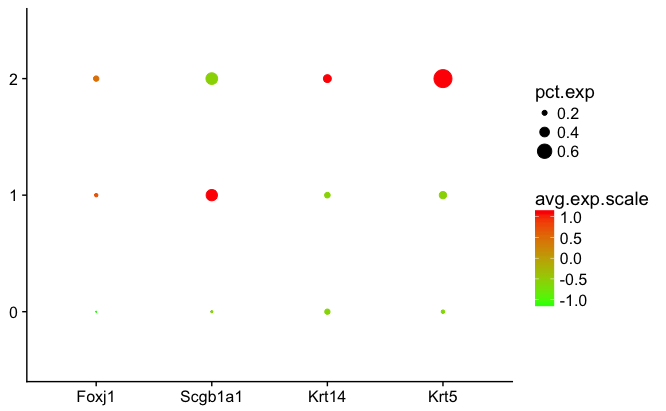

```r
# To change the y-axis to show raw counts, add use.raw = T.
DotPlot(subtiss, genes_to_check, plot.legend = T, cols.use = c("green","red"))
```

How big are the clusters?

```r
table(subtiss@ident)
```

```
 0  1  2
66 53 37
```

## Checking for batch effects

Color by metadata, like plate barcode, to check for batch effects.

```r
#TSNEPlot(object = subtiss, do.return = TRUE, group.by = "channel")
```

Print a table showing the count of cells in each identity category from each plate.

```r
#table(as.character(subtiss@ident), as.character(subtiss@meta.data$channel))
```

### Assigning subcell_ontology_classs

For the subsets, we produce subcell_ontology_classs. These will be written back as metadata in the original object, so we can see all subcell_ontology_classs together.

If some of the clusters you find in the subset deserve additional cell_ontology_class, you can add that right here. Use NA for clusters for which no subcell_ontology_class is needed.

```r
subcluster.ids <- c(0, 1, 2)
subcell_ontology_class <- c("epithelial - other","secretory", "basal")
#validate_cell_ontology(subcell_ontology_class)
subcell_ontology_id = convert_to_cell_ontology_id(subcell_ontology_class)
subtiss@meta.data[,'cell_ontology_class'] <- plyr::mapvalues(x = subtiss@ident, from = subcluster.ids, to = subcell_ontology_class)
subtiss@meta.data[,'cell_ontology_id'] <- plyr::mapvalues(x = subtiss@ident, from = subcluster.ids, to = subcell_ontology_id)
tiss@meta.data[subtiss@cell.names,'cell_ontology_class'] <- as.character(subtiss@meta.data$cell_ontology_class)
```

```
invalid factor level, NA generated
```

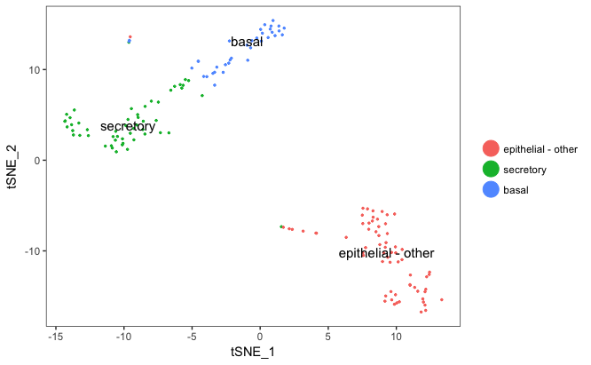

```r
tiss@meta.data[subtiss@cell.names,'cell_ontology_id'] <- as.character(subtiss@meta.data$cell_ontology_id)
TSNEPlot(object = subtiss, do.label = TRUE, pt.size = 0.5, group.by='cell_ontology_class')
```

```r
#TRACHEA SUPP FIGURE 6
```

```r
filename = here('00_data_ingest', '03_tissue_annotation_csv',
                     paste0(tissue_of_interest, "_facs_annotation.csv"))
write.csv(FetchData(tiss, c('plate.barcode','cell_ontology_class','cell_ontology_id', 'free_annotation', 'tSNE_1', 'tSNE_2')), file=filename)
```